# Multivariable Regression

## Poisson Distribution

- The poisson distribution is a useful model for counts and rates.
- Here a rate is count per some monitoring time.
- Some examples - uses of the poisson distribution.
1. Modelling web traffic hits.
2. Incidence rates.
3. Approximating binomial probabilities with small p and large n.
4. Analyzing contingency table data.
- The mean of the poisson is lambda and the variance is lambda i.e. mean = variance = lambda.
- The poisson turns to a normal as the mean becomes larger.

## Example of simulation

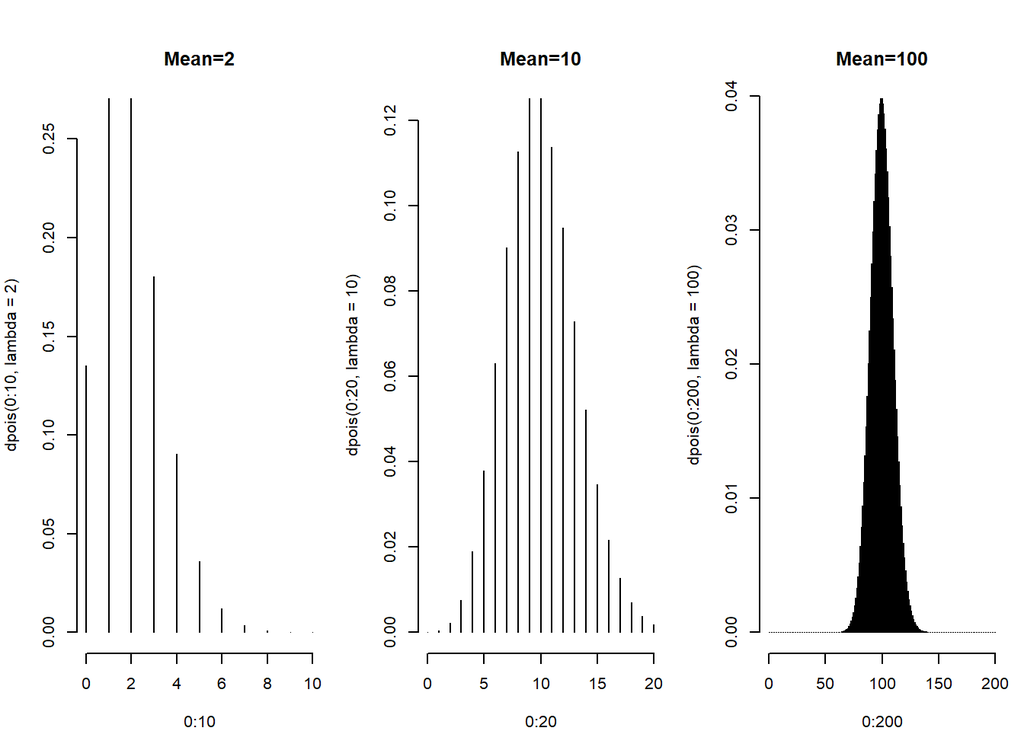

```r
par(mfrow=c(1,3),mar=c(4,4,2,1),oma=c(0,0,2,0))
plot(0:10,dpois(0:10,lambda=2),type="h",main="Mean=2",frame=FALSE)
plot(0:20,dpois(0:20,lambda=10),type="h",main="Mean=10",frame=FALSE)
plot(0:200,dpois(0:200,lambda=100),type="h",main="Mean=100",frame=FALSE)
```

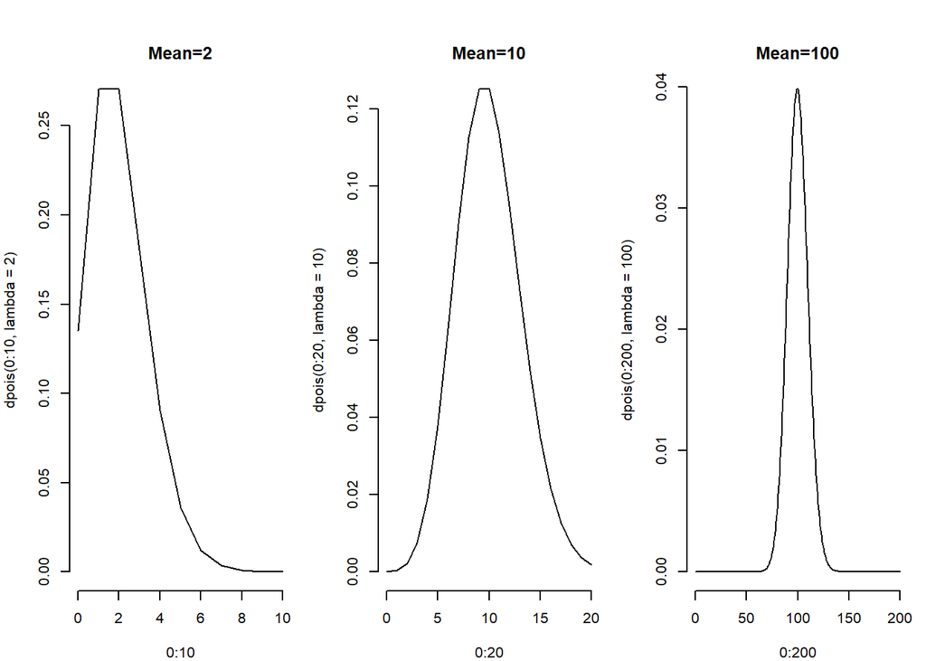

```r
#You can specify type="l", that gives a line.
par(mfrow=c(1,3),mar=c(4,4,2,1),oma=c(0,0,2,0))
plot(0:10,dpois(0:10,lambda=2),type="l",main="Mean=2",frame=FALSE)
plot(0:20,dpois(0:20,lambda=10),type="l",main="Mean=10",frame=FALSE)
plot(0:200,dpois(0:200,lambda=100),type="l",main="Mean=100",frame=FALSE)
```

## Show that the mean and variance of the poisson are equal.

```r
x <-0:10000
lambda <-3
mu <-sum(x*dpois(x,lambda=lambda))
sigmasq <-sum((x-mu)^2*dpois(x,lambda=lambda))
c(mu,sigmasq)
```

```
[1] 3 3
```

- Geometric mean is just exponentiating the arithmetic mean.

## How to fit functions using linear models

### Simulated Example

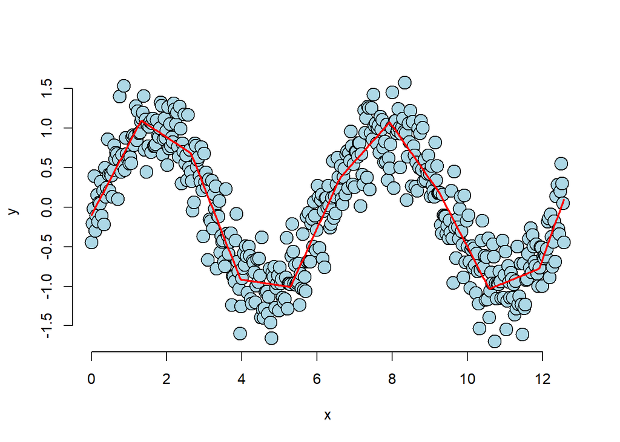

```r
n <-500
x <-seq(0,4*pi,length=n)
y <-sin(x)+rnorm(n,sd=0.3)
knots <-seq(0,8*pi,length=20)
splineTerms <-sapply(knots,function(knot)(x>knot)*(x-knot))
xMat <-cbind(1,x,splineTerms)
yhat <-predict(lm(y~xMat-1))
plot(x,y,frame=FALSE,pch=21,bg="lightblue",cex=2)
lines(x,yhat,col="red",lwd=2)
```

## Adding squared terms

- Adding squared terms makes it continuously differentiable at the knot points.
- Adding cubic terms makes it twice continuously differentiable at the knot points etcetera.

### The code is identical

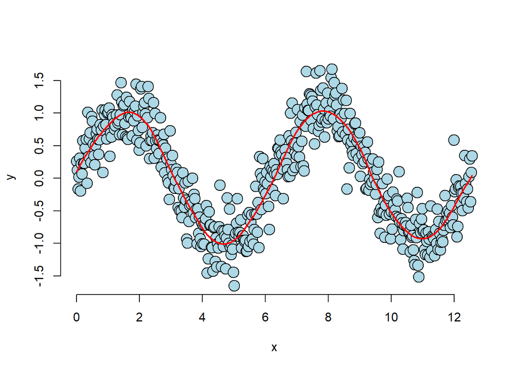

```r
n <-500
x <-seq(0,4*pi,length=n)
y <-sin(x)+rnorm(n,sd=0.3)
knots <-seq(0,8*pi,length=20)
splineTerms <-sapply(knots,function(knot)(x>knot)*(x-knot)^2)
xMat <-cbind(1,x,x^2,splineTerms)
yhat <-predict(lm(y~xMat-1))
plot(x,y,frame=FALSE,pch=21,bg="lightblue",cex=2)
lines(x,yhat,col="red",lwd=2)
```

## Notes - Regression Splines

- The collection of regressors is called a basis (building blocks).
- People have spent a lot of time thinking about basis for this kind of problem. So consider this as just a teaser.
- Single knot point terms can fit hockey stick like processes.
- These bases can be used in GLMs as well.
- An issue with this approach is the large number of parameters introduced. Requires some method of so called regularization.
- Problem; fit in lots and lots of knot points.

## Harmonics using linear models

### Chord finder, playing the white keys on a piano from octave C4 - c5.

```r
notes4 <-c(261.63,293.66,329.63,349.23,392.00,440.00,493.88,523.25)
t <-seq(0,2,by=0.001)
n <-length(t)
c4 <-sin(2*pi*notes4[1]*t)
e4 <-sin(2*pi*notes4[3]*t)
g4 <-sin(2*pi*notes4[5]*t)
chord <-c4+e4+g4+rnorm(n,0,0.3)
x <-sapply(notes4,function(freq)sin(2*pi*freq*t))
fit <-lm(chord~x-1)
fit
```

```
Call:
lm(formula = chord ~ x - 1)

Coefficients:
       x1         x2         x3         x4         x5         x6
 1.004956  -0.004379   0.998908  -0.001178   0.988347   0.010941
       x7         x8
-0.003357   0.000168
```

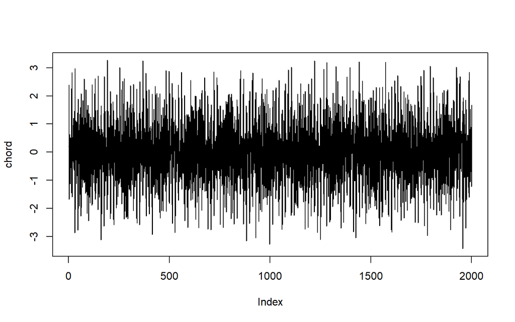

```r
plot(chord,type="l")
```

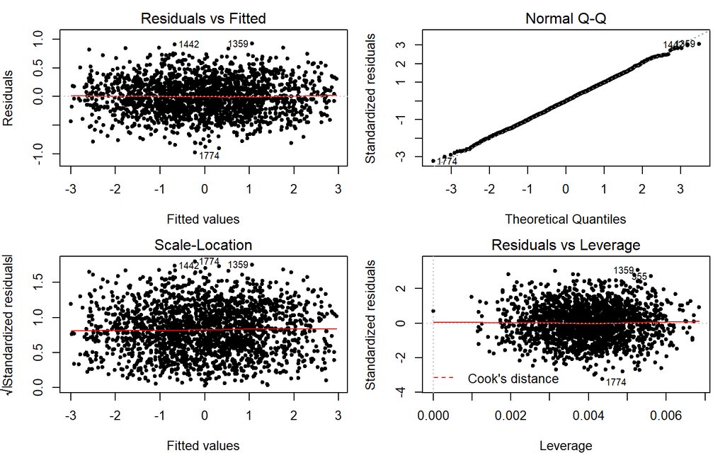

```r
#Diagnostic plots
par(mfrow=c(2,2),mar=c(4,4,2,1))
plot(fit,cex=1,pch=20)
```

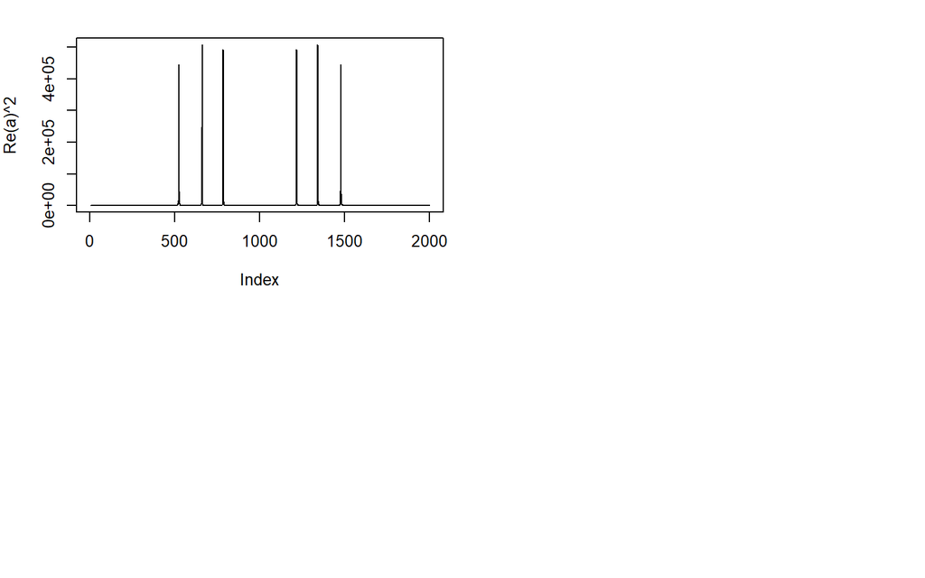

```r
#Discrete Fourier Transform
a <-fft(chord)
plot(Re(a)^2,type="l")
```